# Analiza gier wideo wydanych na przestrzeni lat

Dominika Wiśniewska

## Wstęp

Źródło danych: https://www.kaggle.com/datasets/thedevastator/video-game-sales-and-ratings/data (pobierane w momencie uruchomienia programu)

Kolumny

- Index
- Name
- Platform
- Year_of_Release
- Genre
- Publisher
- NA_Sales
- EU_Sales
- JP_Sales
- Other_Sales
- Global_Sales
- Critic_Score
- Critic_Count
- User_Score
- User_Count
- Developer
- Rating

### Importowanie bibliotek

```python
import kagglehub
import numpy as np
import pandas as pd
import matplotlib.pyplot as plt
import seaborn as sns
```

### Wczytanie danych

```python
path = kagglehub.dataset_download("thedevastator/video-game-sales-and-ratings")

print("Path to dataset files:", path)

path=path+'\\Video_Games.csv'

df= pd.read_csv(path)
```

## Wstępna obróbka

```python
df
```

|  | index | Name | Platform | Year_of_Release | Genre | Publisher | NA_Sales | EU_Sales | JP_Sales | Other_Sales | Global_Sales | Critic_Score | Critic_Count | User_Score | User_Count | Developer | Rating |
| --- | --- | --- | --- | --- | --- | --- | --- | --- | --- | --- | --- | --- | --- | --- | --- | --- | --- |
| 0 | 0 | Wii Sports | Wii | 2006.0 | Sports | Nintendo | 41.36 | 28.96 | 3.77 | 8.45 | 82.53 | 76.0 | 51.0 | 8 | 322.0 | Nintendo | E |
| 1 | 1 | Super Mario Bros. | NES | 1985.0 | Platform | Nintendo | 29.08 | 3.58 | 6.81 | 0.77 | 40.24 | NaN | NaN | NaN | NaN | NaN | NaN |
| 2 | 2 | Mario Kart Wii | Wii | 2008.0 | Racing | Nintendo | 15.68 | 12.76 | 3.79 | 3.29 | 35.52 | 82.0 | 73.0 | 8.3 | 709.0 | Nintendo | E |
| 3 | 3 | Wii Sports Resort | Wii | 2009.0 | Sports | Nintendo | 15.61 | 10.93 | 3.28 | 2.95 | 32.77 | 80.0 | 73.0 | 8 | 192.0 | Nintendo | E |
| 4 | 4 | Pokemon Red/Pokemon Blue | GB | 1996.0 | Role-Playing | Nintendo | 11.27 | 8.89 | 10.22 | 1.00 | 31.37 | NaN | NaN | NaN | NaN | NaN | NaN |
| ... | ... | ... | ... | ... | ... | ... | ... | ... | ... | ... | ... | ... | ... | ... | ... | ... | ... |
| 16923 | 16923 | Aliens: Colonial Marines | PS3 | 2013.0 | Shooter | Sega | 0.20 | 0.29 | 0.00 | 0.11 | 0.60 | 43.0 | 25.0 | 3.6 | 295.0 | Gearbox Software | M |
| 16924 | 16924 | Backyard Wrestling: Don't Try This at Home | PS2 | 2003.0 | Fighting | Eidos Interactive | 0.30 | 0.23 | 0.00 | 0.08 | 0.60 | 51.0 | 24.0 | 7.8 | 29.0 | Paradox Development | M |
| 16925 | 16925 | Yakuza: Dead Souls | PS3 | 2011.0 | Shooter | Sega | 0.09 | 0.06 | 0.42 | 0.03 | 0.60 | 64.0 | 55.0 | 7.4 | 69.0 | Ryu ga Gotoku Studios | M |
| 16926 | 16926 | Fight Night Round 2 | XB | 2005.0 | Fighting | Electronic Arts | 0.42 | 0.16 | 0.00 | 0.02 | 0.60 | 88.0 | 48.0 | 8.8 | 27.0 | EA Sports | T |
| 16927 | 16927 | MonHun Nikki: Poka Poka Ailu Mura | PSP | 2010.0 | Role-Playing | Capcom | 0.00 | 0.00 | 0.60 | 0.00 | 0.60 | NaN | NaN | NaN | NaN | NaN | NaN |

16928 rows × 17 columns

```python
df.isna().sum()
```

```
index                 0
Name                  2
Platform              0
Year_of_Release     273
Genre                 2
Publisher            55
NA_Sales              0
EU_Sales              0
JP_Sales              0
Other_Sales           0
Global_Sales          0
Critic_Score       8668
Critic_Count       8668
User_Score         6769
User_Count         9210
Developer          6688
Rating             6836
dtype: int64
```

```python
df.isna().sum().sum()
```

```
47171
```

Usunięcie rekordów z brakującymi danymi

```python
df.dropna(inplace=True)
df
```

|  | index | Name | Platform | Year_of_Release | Genre | Publisher | NA_Sales | EU_Sales | JP_Sales | Other_Sales | Global_Sales | Critic_Score | Critic_Count | User_Score | User_Count | Developer | Rating |
| --- | --- | --- | --- | --- | --- | --- | --- | --- | --- | --- | --- | --- | --- | --- | --- | --- | --- |
| 0 | 0 | Wii Sports | Wii | 2006.0 | Sports | Nintendo | 41.36 | 28.96 | 3.77 | 8.45 | 82.53 | 76.0 | 51.0 | 8 | 322.0 | Nintendo | E |
| 2 | 2 | Mario Kart Wii | Wii | 2008.0 | Racing | Nintendo | 15.68 | 12.76 | 3.79 | 3.29 | 35.52 | 82.0 | 73.0 | 8.3 | 709.0 | Nintendo | E |
| 3 | 3 | Wii Sports Resort | Wii | 2009.0 | Sports | Nintendo | 15.61 | 10.93 | 3.28 | 2.95 | 32.77 | 80.0 | 73.0 | 8 | 192.0 | Nintendo | E |
| 6 | 6 | New Super Mario Bros. | DS | 2006.0 | Platform | Nintendo | 11.28 | 9.14 | 6.50 | 2.88 | 29.80 | 89.0 | 65.0 | 8.5 | 431.0 | Nintendo | E |
| 7 | 7 | Wii Play | Wii | 2006.0 | Misc | Nintendo | 13.96 | 9.18 | 2.93 | 2.84 | 28.92 | 58.0 | 41.0 | 6.6 | 129.0 | Nintendo | E |
| ... | ... | ... | ... | ... | ... | ... | ... | ... | ... | ... | ... | ... | ... | ... | ... | ... | ... |
| 16922 | 16922 | Wave Race: Blue Storm | GC | 2001.0 | Racing | Nintendo | 0.40 | 0.10 | 0.09 | 0.02 | 0.60 | 80.0 | 21.0 | 8.3 | 29.0 | Nintendo | E |
| 16923 | 16923 | Aliens: Colonial Marines | PS3 | 2013.0 | Shooter | Sega | 0.20 | 0.29 | 0.00 | 0.11 | 0.60 | 43.0 | 25.0 | 3.6 | 295.0 | Gearbox Software | M |
| 16924 | 16924 | Backyard Wrestling: Don't Try This at Home | PS2 | 2003.0 | Fighting | Eidos Interactive | 0.30 | 0.23 | 0.00 | 0.08 | 0.60 | 51.0 | 24.0 | 7.8 | 29.0 | Paradox Development | M |
| 16925 | 16925 | Yakuza: Dead Souls | PS3 | 2011.0 | Shooter | Sega | 0.09 | 0.06 | 0.42 | 0.03 | 0.60 | 64.0 | 55.0 | 7.4 | 69.0 | Ryu ga Gotoku Studios | M |
| 16926 | 16926 | Fight Night Round 2 | XB | 2005.0 | Fighting | Electronic Arts | 0.42 | 0.16 | 0.00 | 0.02 | 0.60 | 88.0 | 48.0 | 8.8 | 27.0 | EA Sports | T |

6938 rows × 17 columns

```python
df.info()
```

```
<class 'pandas.core.frame.DataFrame'>
Index: 6938 entries, 0 to 16926
Data columns (total 17 columns):
 #   Column           Non-Null Count  Dtype
---  ------           --------------  -----
 0   index            6938 non-null   int64
 1   Name             6938 non-null   object
 2   Platform         6938 non-null   object
 3   Year_of_Release  6938 non-null   float64
 4   Genre            6938 non-null   object
 5   Publisher        6938 non-null   object
 6   NA_Sales         6938 non-null   float64
 7   EU_Sales         6938 non-null   float64
 8   JP_Sales         6938 non-null   float64
 9   Other_Sales      6938 non-null   float64
 10  Global_Sales     6938 non-null   float64
 11  Critic_Score     6938 non-null   float64
 12  Critic_Count     6938 non-null   float64
 13  User_Score       6938 non-null   object
 14  User_Count       6938 non-null   float64
 15  Developer        6938 non-null   object
 16  Rating           6938 non-null   object
dtypes: float64(9), int64(1), object(7)
memory usage: 975.7+ KB
```

```python
numeric_cols = ['NA_Sales', 'EU_Sales','JP_Sales','Other_Sales','Global_Sales','Critic_Score','Critic_Count','User_Score','User_Count']
df = df.astype({'Year_of_Release': 'int', 'Critic_Count': 'int', 'User_Count': 'int', 'User_Score': 'float64'})
```

Zmiana typów zmiennych dla danych numerycznych

```python
df_sum = df.groupby('Name').agg(
    Critic_Score=('Critic_Score', 'mean'),
    User_Score=('User_Score', 'mean'),
    Global_Sales=('Global_Sales', 'sum'),
    NA_Sales=('NA_Sales', 'sum'),
    EU_Sales=('EU_Sales', 'sum'),
    JP_Sales=('JP_Sales', 'sum'),
    Other_Sales=('Other_Sales', 'sum'),
    Critic_Count=('Critic_Count', 'sum'),
    User_Count=('User_Count', 'sum')
).reset_index()
```

Sumowanie liczby sprzedanych kopii dla gier wypuszczonych na kilku platformach

# Analiza podstawowa

```python
summary=df[numeric_cols].describe()
summary = summary.round(2)
summary
```

|  | NA_Sales | EU_Sales | JP_Sales | Other_Sales | Global_Sales | Critic_Score | Critic_Count | User_Score | User_Count |
| --- | --- | --- | --- | --- | --- | --- | --- | --- | --- |
| count | 6938.00 | 6938.00 | 6938.00 | 6938.00 | 6938.00 | 6938.00 | 6938.00 | 6938.00 | 6938.00 |
| mean | 0.40 | 0.24 | 0.06 | 0.08 | 0.79 | 70.32 | 28.98 | 7.19 | 175.97 |
| std | 0.97 | 0.69 | 0.29 | 0.27 | 1.96 | 13.87 | 19.22 | 1.44 | 589.13 |
| min | 0.00 | 0.00 | 0.00 | 0.00 | 0.01 | 13.00 | 3.00 | 0.50 | 4.00 |
| 25% | 0.06 | 0.02 | 0.00 | 0.01 | 0.11 | 62.00 | 14.00 | 6.50 | 11.00 |
| 50% | 0.15 | 0.06 | 0.00 | 0.02 | 0.30 | 72.00 | 25.00 | 7.50 | 27.00 |
| 75% | 0.40 | 0.21 | 0.01 | 0.07 | 0.75 | 81.00 | 39.00 | 8.20 | 89.00 |
| max | 41.36 | 28.96 | 6.50 | 10.57 | 82.53 | 98.00 | 113.00 | 9.60 | 10665.00 |

```python
df['Platform'].value_counts()
```

```
Platform
PS2     1159
X360     874
PS3      792
PC       655
XB       572
Wii      488
DS       467
PSP      393
GC       352
GBA      246
PS4      242
XOne     162
3DS      159
PS       154
PSV      119
WiiU      90
DC        14
Name: count, dtype: int64
```

```python
df['Year_of_Release'].value_counts()
```

```
Year_of_Release
2008    600
2007    595
2005    570
2009    564
2006    534
2003    504
2004    484
2011    464
2002    462
2010    439
2012    319
2013    270
2001    262
2014    259
2015    214
2016    213
2000    104
1999     30
1998     27
1997     13
1996      7
1994      1
1985      1
1992      1
1988      1
Name: count, dtype: int64
```

# Statystyki na przestrzeni lat

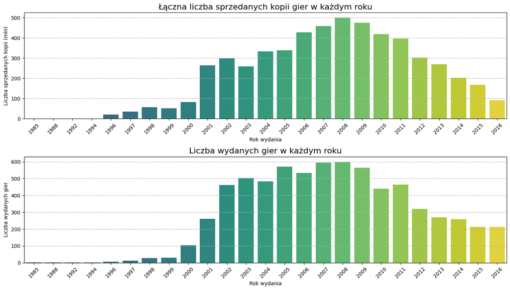

```python
sales = df.groupby('Year_of_Release')['Global_Sales'].sum().sort_index()
games = df['Year_of_Release'].value_counts().sort_index()

plt.figure(figsize=(14, 8))

plt.subplot(2, 1, 1)
sns.barplot(x=sales.index, y=sales.values, palette='viridis', hue=sales.index, legend=False)
plt.title('Łączna liczba sprzedanych kopii gier w każdym roku',fontsize=16)
plt.xlabel('Rok wydania')
plt.ylabel('Liczba sprzedanych kopii (mln)')
plt.xticks(rotation=45)
plt.grid(axis='y', linestyle='--')

plt.subplot(2, 1, 2)
sns.barplot(x=games.index, y=games.values, palette='viridis', hue=games.index, legend=False)
plt.title('Liczba wydanych gier w każdym roku',fontsize=16)
plt.xlabel('Rok wydania')
plt.ylabel('Liczba wydanych gier')
plt.xticks(rotation=45)
plt.grid(axis='y', linestyle='--')

plt.tight_layout()
plt.show()
```

Wnioski:

Lata 2001/2002 - 2011/2012 były najlepszym czasem dla rynku gier

# Ilość gier wydanych na daną platformę

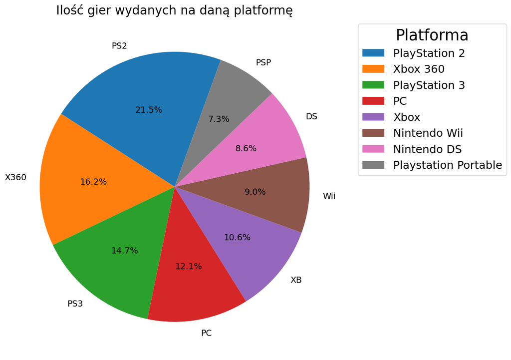

```python
plot = df['Platform'].value_counts().head(8).plot.pie(ylabel="", figsize=(10, 10), autopct='%1.1f%%', textprops={'fontsize': 14}, startangle=70)
labels_ex = ["PlayStation 2", "Xbox 360",
             "PlayStation 3", "PC", "Xbox", "Nintendo Wii",
             "Nintendo DS", "Playstation Portable"]

plt.title(label='Ilość gier wydanych na daną platformę',fontsize=20)

plt.legend(title="Platforma",
           labels=labels_ex,
           fontsize=18,
           title_fontsize = 25,
           bbox_to_anchor=(1.5, 1.0))

plt.show()
```

Wnioski:

Najwięcej gier zostało wydanych na PS2.

Później po kolei mamy Xbox360, PS3 i PC.

# Sprzedaż globalna w zależności od platformy

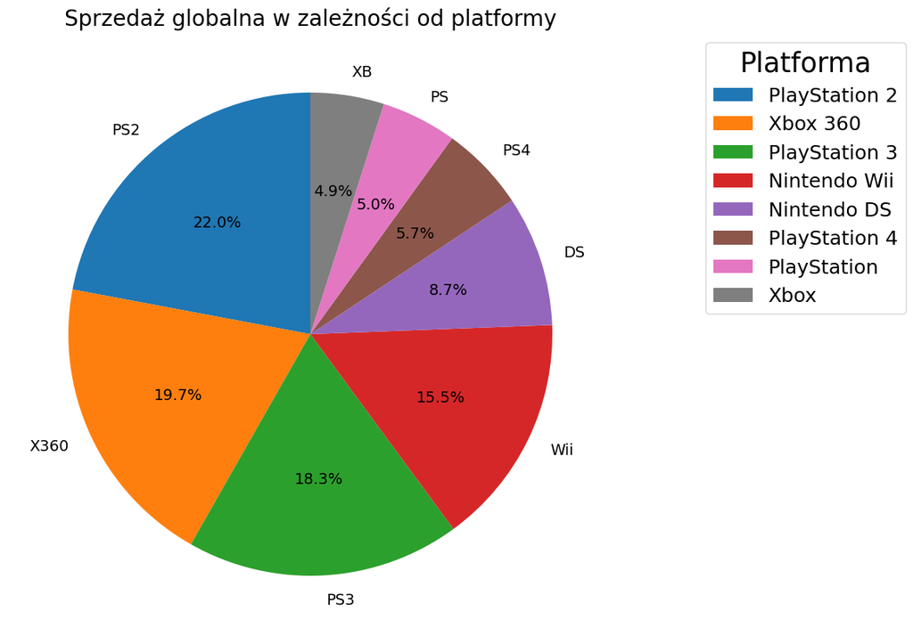

```python
platform_sales = df.groupby('Platform')['Global_Sales'].sum().sort_values(ascending=False).head(8)

plt.figure(figsize=(10, 10))
plt.pie(platform_sales, labels=platform_sales.index, autopct='%1.1f%%', startangle=90, textprops={'fontsize': 14})

labels_ex = ["PlayStation 2", "Xbox 360",
             "PlayStation 3", "Nintendo Wii","Nintendo DS", "PlayStation 4", "PlayStation", "Xbox"]

plt.title(label='Sprzedaż globalna w zależności od platformy',fontsize=20)

plt.legend(title="Platforma",
           labels=labels_ex,
           fontsize=18,
           title_fontsize = 25,
           bbox_to_anchor=(1.5, 1.0))
plt.show()
```

Wnioski:

Najwięcej zarobiły gry wydane na PS2.

Później po kolei mamy Xbox360, PS3 i Wii.

# Sprzedaż gier w różnych regionach świata

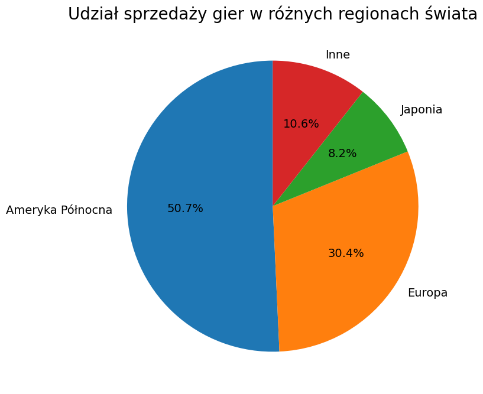

```python
region_sales = df_sum[['NA_Sales', 'EU_Sales', 'JP_Sales', 'Other_Sales']].sum()
region_sales.plot(kind='pie',
                  figsize=(8, 8),
                  autopct='%1.1f%%',
                  startangle=90,
                  labels=['Ameryka Północna', 'Europa', 'Japonia', 'Inne'],
                  textprops={'fontsize': 14}
                  )
plt.title('Udział sprzedaży gier w różnych regionach świata', fontsize=20)
plt.ylabel('')
plt.show()
```

Wnioski:

Ameryka Północna jest głównym konsumentem rynku gier.

# Ilość gier w poszczególnych gatunkach

[figure not shown]

```python
df['Genre'].value_counts().plot.bar(color='skyblue', figsize=(18, 8))
plt.xticks(fontsize=16, rotation=30)
plt.yticks(fontsize=12)
plt.title("Ilość gier w poszczególnych gatunkach", fontsize=20, pad=20)

positions = np.arange(12)
labels = ("Akcja", "Sport", "Inne", "Fabularne", "Strzelanki", "Przygodowe",
          "Wyścigowe", "Platformówki", "Symulatory", "Bijatyki", "Strategie", "Łamigłówki")
plt.xticks(positions, labels)

plt.show()
```

Wnioski:

Zdecydowanie najwięcej zostało wypuszczonych gier z gatunku akcji.

Najmniej wypuszczono gier z gatunku łamigłówek.

# Zestawienie top 20 największych wydawców gier

[figure not shown]

```python
df['Publisher'].value_counts().head(20)[::-1].plot.barh(color='skyblue', figsize=(10, 8))

plt.yticks(fontsize=15)
plt.title('Zestawienie 20 największych wydawców',fontsize=16)
plt.xlabel('Ilość sprzedanych kopii gier (mln)')
plt.show()
```

Wnioski:

Przeważającym liderem jest EA

# Sprzedaż gier top wydawcy gier w czasie

```python
top_publisher = df.groupby('Publisher')['Global_Sales'].sum().idxmax()
top_publisher_sales = df[df['Publisher'] == top_publisher].groupby('Year_of_Release')['Global_Sales'].sum()
```

```
No artists with labels found to put in legend.  Note that artists whose label start with an underscore are ignored when legend() is called with no argument.
```

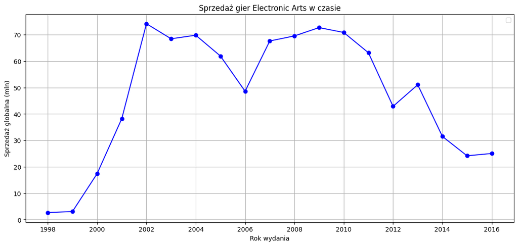

```python
plt.figure(figsize=(14,6))
plt.plot(top_publisher_sales.index, top_publisher_sales, marker='o', color='blue')
plt.title(f'Sprzedaż gier {top_publisher} w czasie')
plt.ylabel('Sprzedaż globalna (mln)')
plt.xlabel('Rok wydania')
plt.grid(True)
years = top_publisher_sales.index[::2]
plt.xticks(ticks=years, labels=[str(year) for year in years])

plt.legend()
plt.show()
```

Wnioski:

Najlepsze okres dla EA to lata 2002 - 2011 z drobnym spadkiem w 2006.

# Najpopularniejsze gry według oceny graczy, oceny krytyków i ilości sprzedanych kopii

```python
Count_User = df_sum[df_sum['User_Count'] >= 90]
Count_Critic = df_sum[df_sum['Critic_Count'] >= 40]

top_5_user_score = Count_User[['Name', 'User_Score', 'Global_Sales']].sort_values(by='User_Score', ascending=False).head(5)
top_5_critic_score = Count_Critic[['Name', 'Critic_Score', 'Global_Sales']].sort_values(by='Critic_Score', ascending=False).head(5)
top_5_sales = df_sum[['Name', 'Global_Sales']].sort_values(by='Global_Sales', ascending=False).head(5)
```

Trzeci kwantyl dla ilości ocen to 89 dla graczy i 39 dla krytyków

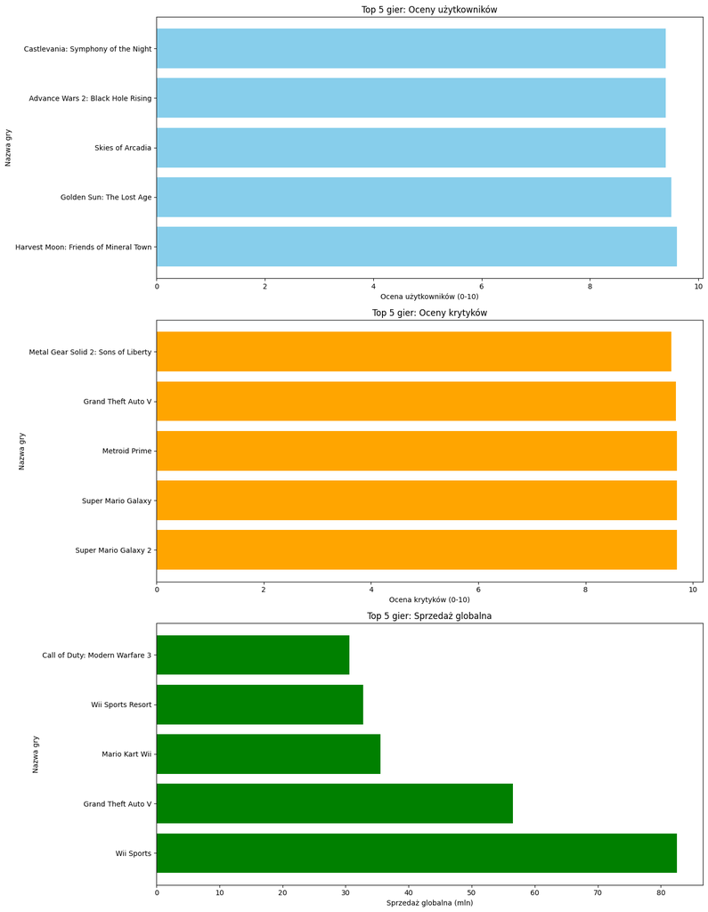

```python
fig, axes = plt.subplots(3, 1, figsize=(14, 18))

# Wykres dla ocen użytkowników
axes[0].barh(top_5_user_score['Name'], top_5_user_score['User_Score'], color='skyblue', label='Ocena użytkowników')
axes[0].set_title('Top 5 gier: Oceny użytkowników')
axes[0].set_xlabel('Ocena użytkowników (0-10)')
axes[0].set_ylabel('Nazwa gry')

# Wykres dla ocen krytyków
axes[1].barh(top_5_critic_score['Name'], top_5_critic_score['Critic_Score'] / 10, color='orange', label='Ocena krytyków')
axes[1].set_title('Top 5 gier: Oceny krytyków')
axes[1].set_xlabel('Ocena krytyków (0-10)')
axes[1].set_ylabel('Nazwa gry')

# Wykres dla sprzedaży globalnej
axes[2].barh(top_5_sales['Name'], top_5_sales['Global_Sales'], color='green', label='Sprzedaż globalna (mln)')
axes[2].set_title('Top 5 gier: Sprzedaż globalna')
axes[2].set_xlabel('Sprzedaż globalna (mln)')
axes[2].set_ylabel('Nazwa gry')

plt.tight_layout()
plt.show()
```

Wnioski:

Gry uwielbiane przez graczy nie pokrywają się z grami uwielbianymi przez krytyków.

Tylko jedna z gier wysoko ocenianych przez krytyków znalazła się w zestawieniu najlepiej sprzedającyh się gier.

Wynik jest uzależniony od minimalnej ilości ocen jaka zostanie ustawiona.

# Proporcja sprzedaży w różnych regionach dla najlepiej sprzedającej się gry

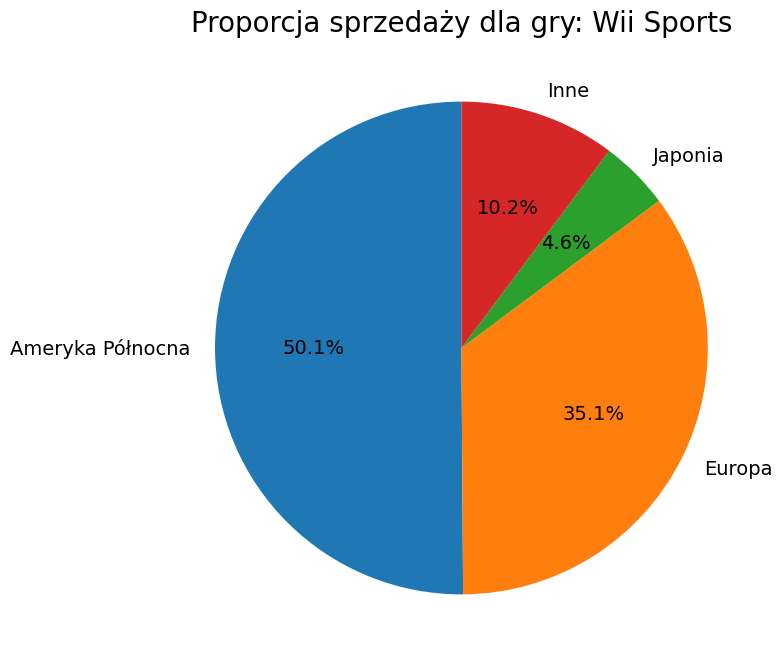

```python
top_game = df_sum.loc[df_sum['Global_Sales'].idxmax()]

regions = ['NA_Sales', 'EU_Sales', 'JP_Sales', 'Other_Sales']

region_values = top_game[regions]
region_values = region_values.astype(float)

region_values.plot(kind='pie',
                  figsize=(8, 8),
                  autopct='%1.1f%%',
                  startangle=90,
                  labels=['Ameryka Północna', 'Europa', 'Japonia', 'Inne'],
                  textprops={'fontsize': 14})
plt.title(f"Proporcja sprzedaży dla gry: {top_game['Name']}", fontsize=20)
plt.ylabel('')
plt.show()
```

Wnioski:

Gra głównie sprzedawała się w Ameryce Północnej

# Relacja między ocenami krytyków i użytkowników

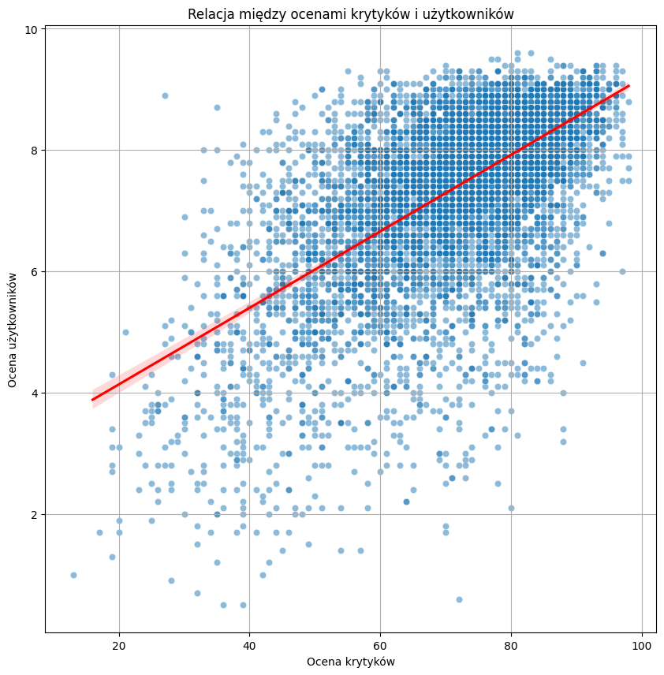

```python
plt.figure(figsize=(10, 10))
sns.scatterplot(data=df, x='Critic_Score', y='User_Score', alpha=0.5)
sns.regplot(data=df_sum, x='Critic_Score', y='User_Score', scatter=False, color='red')
plt.title('Relacja między ocenami krytyków i użytkowników')
plt.xlabel('Ocena krytyków')
plt.ylabel('Ocena użytkowników')
plt.grid(True)
plt.show()
```

Wnioski: Większość gier została podobnie oceniona przez graczy, jak i przez krytyków, jednak wyraźnie widać również wiele odstępstw od tego

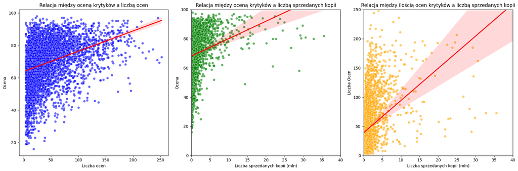

```python
plt.figure(figsize=(18, 6))

plt.subplot(1, 3, 1)
sns.scatterplot(data=df_sum, x='Critic_Count', y='Critic_Score', color='blue', alpha=0.6)
sns.regplot(data=df_sum, x='Critic_Count', y='Critic_Score', scatter=False, color='red')
plt.title('Relacja między oceną krytyków a liczbą ocen')
plt.xlabel('Liczba ocen')
plt.ylabel('Ocena')

plt.subplot(1, 3, 2)
sns.scatterplot(data=df_sum, x='Global_Sales', y='Critic_Score', color='green', alpha=0.6)
sns.regplot(data=df_sum, x='Global_Sales', y='Critic_Score', scatter=False, color='red')
plt.title('Relacja między oceną krytyków a liczbą sprzedanych kopii')
plt.xlabel('Liczba sprzedanych kopii (mln)')
plt.ylabel('Ocena')
plt.ylim(0, 100)
plt.xlim(0, 40)

plt.subplot(1, 3, 3)
sns.scatterplot(data=df_sum, x='Global_Sales', y='Critic_Count', color='orange', alpha=0.6)
sns.regplot(data=df_sum, x='Global_Sales', y='Critic_Count', scatter=False, color='red')
plt.title('Relacja między ilością ocen krytyków a liczbą sprzedanych kopii')
plt.xlabel('Liczba sprzedanych kopii (mln)')
plt.ylabel('Liczba Ocen')
plt.ylim(0, 250)
plt.xlim(0, 40)

plt.tight_layout()
plt.show()
```

Wniosek: Większa ilość ocen od krytyków koreluje z wyższą oceną gry, a obie te metryki są powiązane z większą ilością sprzedanych kopii

# Proporcja gier w kategoriach wiekowych

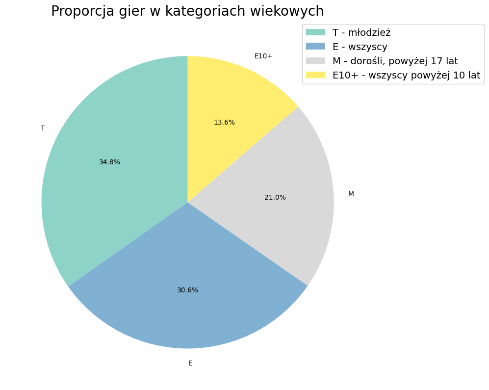

```python
rating_counts = df['Rating'].value_counts().head(4)

plt.figure(figsize=(10, 10))
rating_counts.plot(kind='pie', autopct='%1.1f%%', startangle=90, cmap='Set3', legend=True)
plt.title('Proporcja gier w kategoriach wiekowych', fontsize=20)
plt.ylabel('')
labels_ex = ["T - młodzież", "E - wszyscy",
             "M - dorośli, powyżej 17 lat", "E10+ - wszyscy powyżej 10 lat"]
plt.legend(labels=labels_ex,
           fontsize=14,
           bbox_to_anchor=(0.8, 1.0))
plt.tight_layout()
plt.show()
```

Wnioski:

Mniej więcej równy udział mają gry dla młodzieży i dla wszystkich.

Kategoria E10+ ma mniejszy udział, najpewniej z powodu mniejszej popularności tego oznaczenia.

```python
df['Rating'].value_counts()
```

```
Rating
T       2411
E       2120
M       1458
E10+     946
AO         1
K-A        1
RP         1
Name: count, dtype: int64
```

Pozostałe oznaczenia:

AO - Adults only, zarezerwowane dla najbardziej brutalnych czy graficznych gier

K-A - Kids to adults, zastąpione póżniej przez E

RP - Rating pending, gra jest w trakcie weryfikacji jaką kategorię jej przypisać

# Top 4 gatunki gier z podziałem na kategorie wiekowe

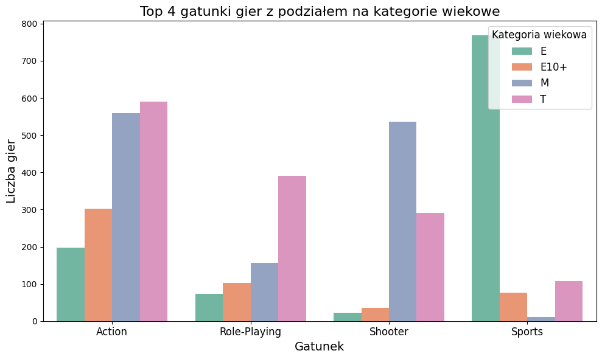

```python
top_genres = df['Genre'].value_counts().nlargest(4).index
top_ratings = df['Rating'].value_counts().nlargest(4).index

filtered_df = df[df['Genre'].isin(top_genres) & df['Rating'].isin(top_ratings)]
genre_rating_counts = filtered_df.groupby(['Genre', 'Rating']).size().reset_index(name='Count')

plt.figure(figsize=(10, 6))
sns.barplot(
    data=genre_rating_counts,
    x='Genre',
    y='Count',
    hue='Rating',
    palette='Set2'
)

plt.title('Top 4 gatunki gier z podziałem na kategorie wiekowe', fontsize=16)
plt.xlabel('Gatunek', fontsize=14)
plt.ylabel('Liczba gier', fontsize=14)
plt.legend(title='Kategoria wiekowa', fontsize=12, title_fontsize=12, loc='upper right')
plt.xticks(fontsize=12)
plt.tight_layout()
plt.show()
```

Wnioski:

W kategori gier akcji najwięcej jest gier z kategori T i M.

W kategori gier RPG najwięcej jest gier z kategori T.

W kategori strzelanek najwięcej jest gier z kategori M.

W kategori gier sportowych zdecydowanie przeważają gry z kategori E.